# Unsupervised Learning: Trade & Ahead

## Problem Statement

### Context

The stock market has consistently proven to be a good place to invest in and save for the future. There are a lot of compelling reasons to invest in stocks. It can help in fighting inflation, create wealth, and also provides some tax benefits. Good steady returns on investments over a long period of time can also grow a lot more than seems possible. Also, thanks to the power of compound interest, the earlier one starts investing, the larger the corpus one can have for retirement. Overall, investing in stocks can help meet life's financial aspirations.

It is important to maintain a diversified portfolio when investing in stocks in order to maximise earnings under any market condition. Having a diversified portfolio tends to yield higher returns and face lower risk by tempering potential losses when the market is down. It is often easy to get lost in a sea of financial metrics to analyze while determining the worth of a stock, and doing the same for a multitude of stocks to identify the right picks for an individual can be a tedious task. By doing a cluster analysis, one can identify stocks that exhibit similar characteristics and ones which exhibit minimum correlation. This will help investors better analyze stocks across different market segments and help protect against risks that could make the portfolio vulnerable to losses.

### Objective

Trade&Ahead is a financial consultancy firm who provide their customers with personalized investment strategies. They have hired you as a Data Scientist and provided you with data comprising stock price and some financial indicators for a few companies listed under the New York Stock Exchange. They have assigned you the tasks of analyzing the data, grouping the stocks based on the attributes provided, and sharing insights about the characteristics of each group.

### Data Dictionary

- Ticker Symbol: An abbreviation used to uniquely identify publicly traded shares of a particular stock on a particular stock market
- Company: Name of the company
- GICS Sector: The specific economic sector assigned to a company by the Global Industry Classification Standard (GICS) that best defines its business operations
- GICS Sub Industry: The specific sub-industry group assigned to a company by the Global Industry Classification Standard (GICS) that best defines its business operations
- Current Price: Current stock price in dollars
- Price Change: Percentage change in the stock price in 13 weeks
- Volatility: Standard deviation of the stock price over the past 13 weeks
- ROE: A measure of financial performance calculated by dividing net income by shareholders' equity (shareholders' equity is equal to a company's assets minus its debt)
- Cash Ratio: The ratio of a company's total reserves of cash and cash equivalents to its total current liabilities
- Net Cash Flow: The difference between a company's cash inflows and outflows (in dollars)
- Net Income: Revenues minus expenses, interest, and taxes (in dollars)
- Earnings Per Share: Company's net profit divided by the number of common shares it has outstanding (in dollars)
- Estimated Shares Outstanding: Company's stock currently held by all its shareholders
- P/E Ratio: Ratio of the company's current stock price to the earnings per share
- P/B Ratio: Ratio of the company's stock price per share by its book value per share (book value of a company is the net difference between that company's total assets and total liabilities)

## Importing necessary libraries and data

```python
# Installing the libraries with the specified version.
# uncomment and run the following line if Google Colab is being used
# !pip install scikit-learn==1.2.2 seaborn==0.13.1 matplotlib==3.7.1 numpy==1.25.2 pandas==1.5.3 yellowbrick==1.5 -q --user
```

```python
import numpy as np
import pandas as pd
import matplotlib.pyplot as plt
import seaborn as sns

from sklearn.preprocessing import StandardScaler

from sklearn.cluster import KMeans
from sklearn.metrics import silhouette_score
from scipy.spatial.distance import cdist, pdist

from sklearn.cluster import AgglomerativeClustering
from scipy.cluster.hierarchy import dendrogram, linkage, cophenet

sns.set_theme(palette='Accent')

import warnings
warnings.filterwarnings('ignore')
```

```python
# Installing the libraries with the specified version.
# uncomment and run the following lines if Jupyter Notebook is being used
# !pip install scikit-learn==1.2.2 seaborn==0.13.1 matplotlib==3.7.1 numpy==1.25.2 pandas==1.5.2 yellowbrick==1.5 -q --user
# !pip install --upgrade -q jinja2
```

**Note**: *After running the above cell, kindly restart the notebook kernel and run all cells sequentially from the start again.*

```python
df = pd.read_csv("stock_data.csv")
df.head()
```

|  | Ticker Symbol | Security | GICS Sector | GICS Sub Industry | Current Price | Price Change | Volatility | ROE | Cash Ratio | Net Cash Flow | Net Income | Earnings Per Share | Estimated Shares Outstanding | P/E Ratio | P/B Ratio |
| --- | --- | --- | --- | --- | --- | --- | --- | --- | --- | --- | --- | --- | --- | --- | --- |
| 0 | AAL | American Airlines Group | Industrials | Airlines | 42.349998 | 9.999995 | 1.687151 | 135 | 51 | -604000000 | 7610000000 | 11.39 | 6.681299e+08 | 3.718174 | -8.784219 |
| 1 | ABBV | AbbVie | Health Care | Pharmaceuticals | 59.240002 | 8.339433 | 2.197887 | 130 | 77 | 51000000 | 5144000000 | 3.15 | 1.633016e+09 | 18.806350 | -8.750068 |
| 2 | ABT | Abbott Laboratories | Health Care | Health Care Equipment | 44.910000 | 11.301121 | 1.273646 | 21 | 67 | 938000000 | 4423000000 | 2.94 | 1.504422e+09 | 15.275510 | -0.394171 |
| 3 | ADBE | Adobe Systems Inc | Information Technology | Application Software | 93.940002 | 13.977195 | 1.357679 | 9 | 180 | -240840000 | 629551000 | 1.26 | 4.996437e+08 | 74.555557 | 4.199651 |
| 4 | ADI | Analog Devices, Inc. | Information Technology | Semiconductors | 55.320000 | -1.827858 | 1.701169 | 14 | 272 | 315120000 | 696878000 | 0.31 | 2.247994e+09 | 178.451613 | 1.059810 |

## Data Overview

- Observations
- Sanity checks

```python
df.shape
```

```
(340, 15)
```

The dataset has 15 columns and 340 rows of data.

```python
df.info()
```

```
<class 'pandas.core.frame.DataFrame'>
RangeIndex: 340 entries, 0 to 339
Data columns (total 15 columns):
 #   Column                        Non-Null Count  Dtype
---  ------                        --------------  -----
 0   Ticker Symbol                 340 non-null    object
 1   Security                      340 non-null    object
 2   GICS Sector                   340 non-null    object
 3   GICS Sub Industry             340 non-null    object
 4   Current Price                 340 non-null    float64
 5   Price Change                  340 non-null    float64
 6   Volatility                    340 non-null    float64
 7   ROE                           340 non-null    int64
 8   Cash Ratio                    340 non-null    int64
 9   Net Cash Flow                 340 non-null    int64
 10  Net Income                    340 non-null    int64
 11  Earnings Per Share            340 non-null    float64
 12  Estimated Shares Outstanding  340 non-null    float64
 13  P/E Ratio                     340 non-null    float64
 14  P/B Ratio                     340 non-null    float64
dtypes: float64(7), int64(4), object(4)
memory usage: 40.0+ KB
```

There are no missing values.

```python
df.describe().T
```

|  | count | mean | std | min | 25% | 50% | 75% | max |
| --- | --- | --- | --- | --- | --- | --- | --- | --- |
| Current Price | 340.0 | 8.086234e+01 | 9.805509e+01 | 4.500000e+00 | 3.855500e+01 | 5.970500e+01 | 9.288000e+01 | 1.274950e+03 |
| Price Change | 340.0 | 4.078194e+00 | 1.200634e+01 | -4.712969e+01 | -9.394838e-01 | 4.819505e+00 | 1.069549e+01 | 5.505168e+01 |
| Volatility | 340.0 | 1.525976e+00 | 5.917984e-01 | 7.331632e-01 | 1.134878e+00 | 1.385593e+00 | 1.695549e+00 | 4.580042e+00 |
| ROE | 340.0 | 3.959706e+01 | 9.654754e+01 | 1.000000e+00 | 9.750000e+00 | 1.500000e+01 | 2.700000e+01 | 9.170000e+02 |
| Cash Ratio | 340.0 | 7.002353e+01 | 9.042133e+01 | 0.000000e+00 | 1.800000e+01 | 4.700000e+01 | 9.900000e+01 | 9.580000e+02 |
| Net Cash Flow | 340.0 | 5.553762e+07 | 1.946365e+09 | -1.120800e+10 | -1.939065e+08 | 2.098000e+06 | 1.698108e+08 | 2.076400e+10 |
| Net Income | 340.0 | 1.494385e+09 | 3.940150e+09 | -2.352800e+10 | 3.523012e+08 | 7.073360e+08 | 1.899000e+09 | 2.444200e+10 |
| Earnings Per Share | 340.0 | 2.776662e+00 | 6.587779e+00 | -6.120000e+01 | 1.557500e+00 | 2.895000e+00 | 4.620000e+00 | 5.009000e+01 |
| Estimated Shares Outstanding | 340.0 | 5.770283e+08 | 8.458496e+08 | 2.767216e+07 | 1.588482e+08 | 3.096751e+08 | 5.731175e+08 | 6.159292e+09 |
| P/E Ratio | 340.0 | 3.261256e+01 | 4.434873e+01 | 2.935451e+00 | 1.504465e+01 | 2.081988e+01 | 3.176476e+01 | 5.280391e+02 |
| P/B Ratio | 340.0 | -1.718249e+00 | 1.396691e+01 | -7.611908e+01 | -4.352056e+00 | -1.067170e+00 | 3.917066e+00 | 1.290646e+02 |

I would need to scale the data regardless, but certainly needed.

## Exploratory Data Analysis (EDA)

- EDA is an important part of any project involving data.
- It is important to investigate and understand the data better before building a model with it.
- A few questions have been mentioned below which will help you approach the analysis in the right manner and generate insights from the data.
- A thorough analysis of the data, in addition to the questions mentioned below, should be done.

**Questions**:

1. What does the distribution of stock prices look like?
2. The stocks of which economic sector have seen the maximum price increase on average?
3. How are the different variables correlated with each other?
4. Cash ratio provides a measure of a company's ability to cover its short-term obligations using only cash and cash equivalents. How does the average cash ratio vary across economic sectors?
5. P/E ratios can help determine the relative value of a company's shares as they signify the amount of money an investor is willing to invest in a single share of a company per dollar of its earnings. How does the P/E ratio vary, on average, across economic sectors?

```python
numeric_columns = df.select_dtypes(include=['number']).columns.tolist()
print(numeric_columns)
```

```
['Current Price', 'Price Change', 'Volatility', 'ROE', 'Cash Ratio', 'Net Cash Flow', 'Net Income', 'Earnings Per Share', 'Estimated Shares Outstanding', 'P/E Ratio', 'P/B Ratio']
```

```python
df1 = pd.DataFrame(numeric_columns)
```

```python
# function to create labeled barplots


def labeled_barplot(data, feature, perc=False, n=None):
    """
    Barplot with percentage at the top

    data: dataframe
    feature: dataframe column
    perc: whether to display percentages instead of count (default is False)
    n: displays the top n category levels (default is None, i.e., display all levels)
    """

    total = len(data[feature])  # length of the column
    count = data[feature].nunique()
    if n is None:
        plt.figure(figsize=(count + 1, 5))
    else:
        plt.figure(figsize=(n + 1, 5))

    plt.xticks(rotation=90, fontsize=15)
    ax = sns.countplot(
        data=data,
        x=feature,
        hue="GICS Sector",
        palette="Paired",
        order=data[feature].value_counts().index[:n].sort_values(),
    )

    for p in ax.patches:
        if perc == True:
            label = "{:.1f}%".format(
                100 * p.get_height() / total
            )  # percentage of each class of the category
        else:
            label = p.get_height()  # count of each level of the category

        x = p.get_x() + p.get_width() / 2  # width of the plot
        y = p.get_height()  # height of the plot

        ax.annotate(
            label,
            (x, y),
            ha="center",
            va="center",
            size=12,
            xytext=(0, 5),
            textcoords="offset points",
        )  # annotate the percentage

    plt.show()  # show the plot
```

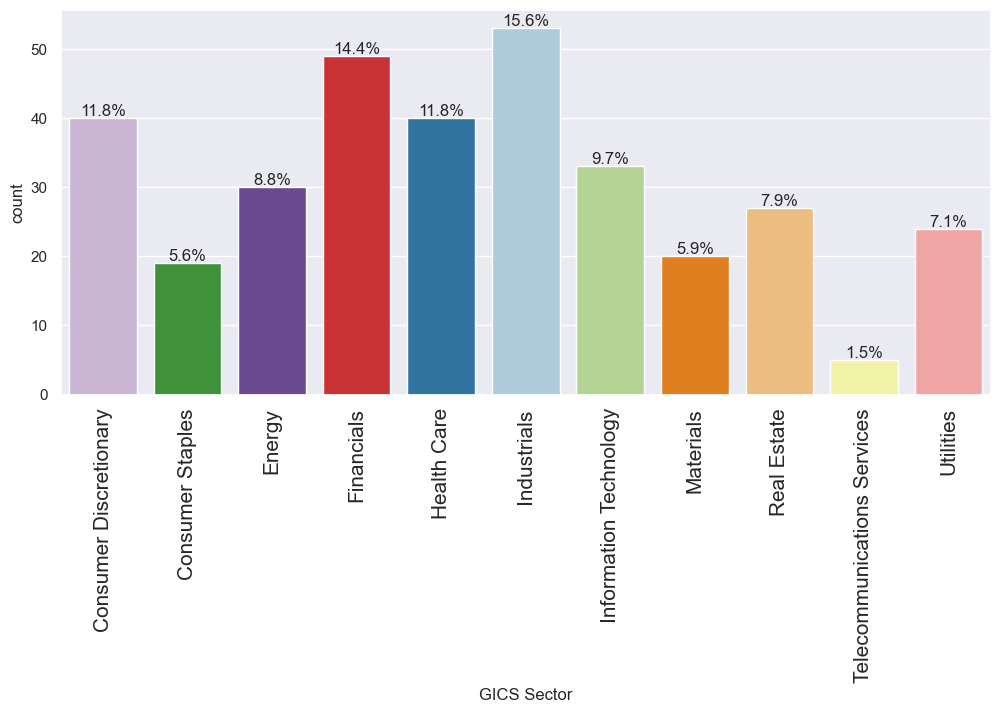

```python
labeled_barplot(df, "GICS Sector", perc=True);
```

#### Securities by market sector

```python
def histogram_boxplot(data, feature, figsize=(12, 7), kde=False, bins=None):
    """
    Boxplot and histogram combined

    data: dataframe
    feature: dataframe column
    figsize: size of figure (default (12,7))
    kde: whether to the show density curve (default False)
    bins: number of bins for histogram (default None)
    """
    f2, (ax_box2, ax_hist2) = plt.subplots(
        nrows=2,  # Number of rows of the subplot grid= 2
        sharex=True,  # x-axis will be shared among all subplots
        gridspec_kw={"height_ratios": (0.25, 0.75)},
        figsize=figsize,
    )  # creating the 2 subplots
    sns.boxplot(
        data=data, x=feature, ax=ax_box2, showmeans=True, color="violet"
    )  # boxplot will be created and a star will indicate the mean value of the column
    sns.histplot(
        data=data, x=feature, kde=kde, ax=ax_hist2, bins=bins, palette="winter"
    ) if bins else sns.histplot(
        data=data, x=feature, kde=kde, ax=ax_hist2
    )  # For histogram
    ax_hist2.axvline(
        data[feature].mean(), color="green", linestyle="--"
    )  # Add mean to the histogram
    ax_hist2.axvline(
        data[feature].median(), color="black", linestyle="-"
    )  # Add median to the histogram
```

#### Current Price

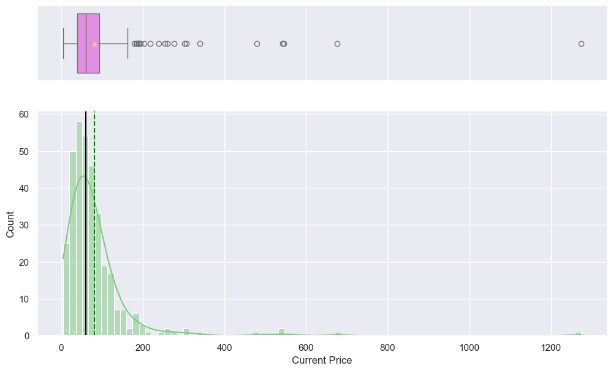

```python
histogram_boxplot(df, feature="Current Price", figsize=(12, 7), kde=True, bins=None)
```

#### Price Change

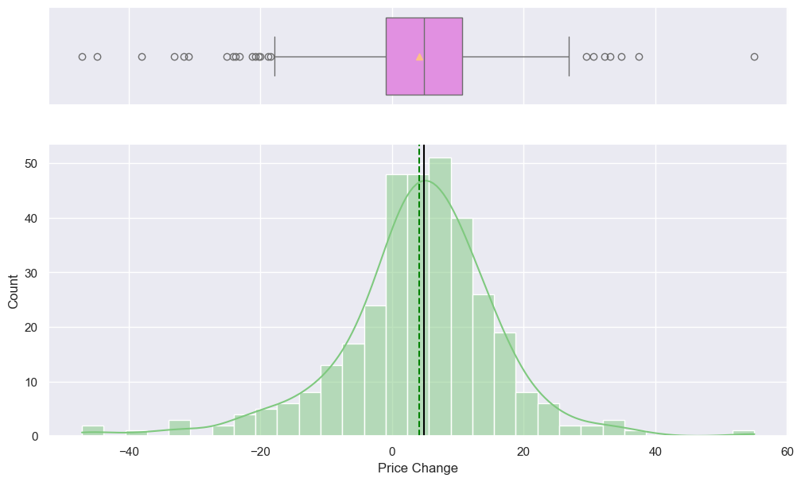

```python
histogram_boxplot(df, feature="Price Change", figsize=(12, 7), kde=True, bins=None)
```

#### Volatility

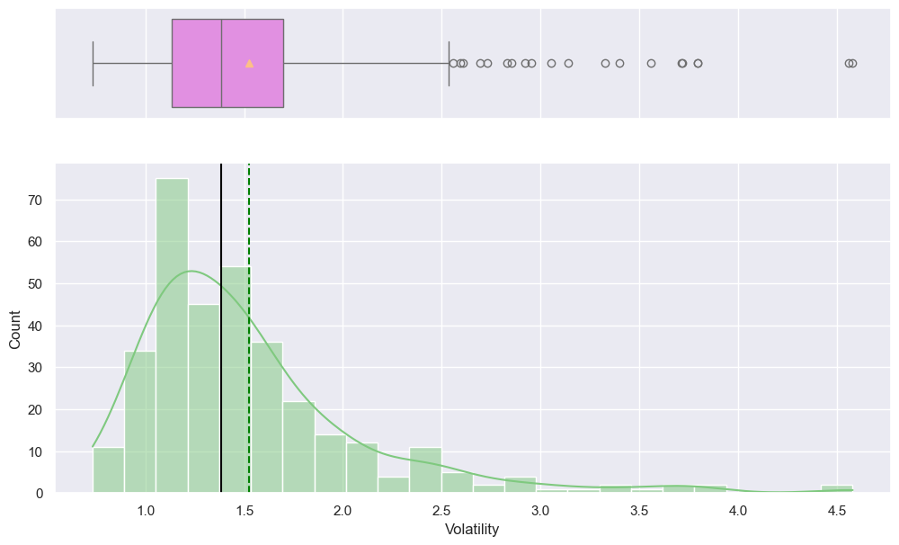

```python
histogram_boxplot(df, feature="Volatility", figsize=(12, 7), kde=True, bins=None)
```

#### ROE

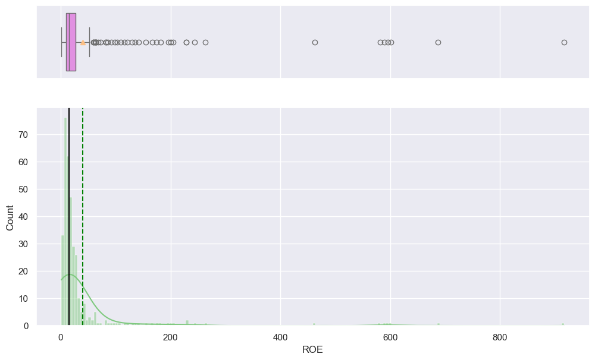

```python
histogram_boxplot(df, feature="ROE", figsize=(12, 7), kde=True, bins=None)
```

#### Cash Ratio

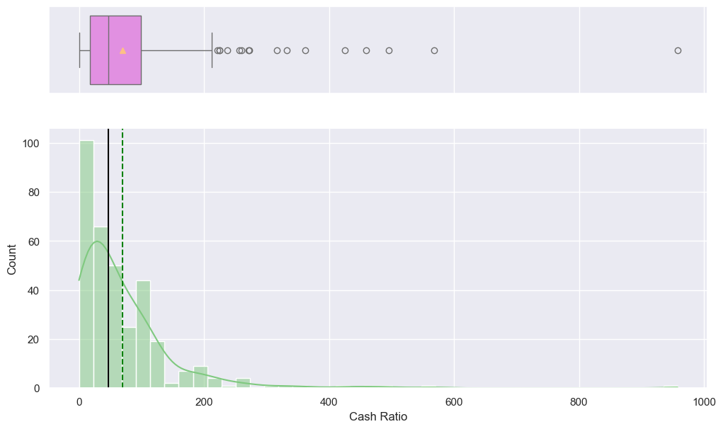

```python
histogram_boxplot(df, feature="Cash Ratio", figsize=(12, 7), kde=True, bins=None)
```

#### Net Cash Flow

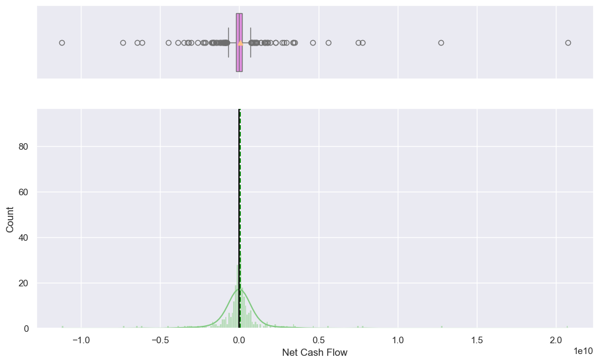

```python
histogram_boxplot(df, feature="Net Cash Flow", figsize=(12, 7), kde=True, bins=None)
```

So far all of the features have issues with outliers, but Net Cash Flow is very bad.

#### Net Income

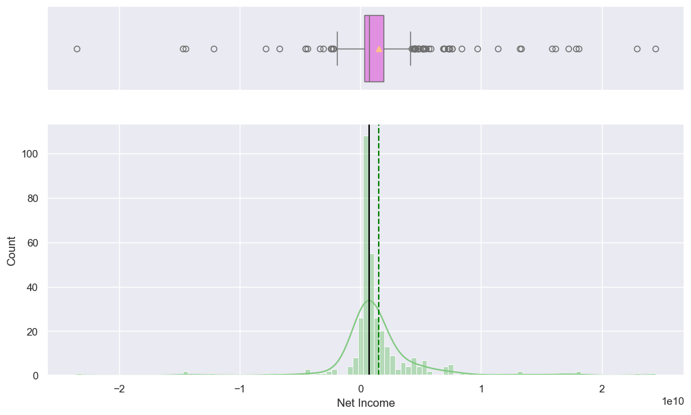

```python
histogram_boxplot(df, feature="Net Income", figsize=(12, 7), kde=True, bins=None)
```

#### Earnings Per Share

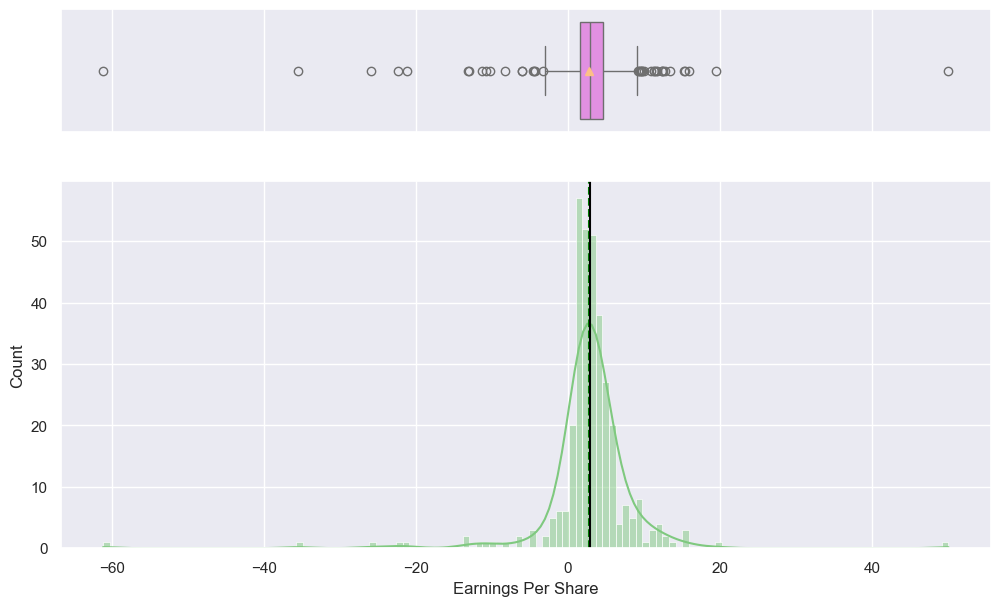

```python
histogram_boxplot(df, feature="Earnings Per Share", figsize=(12, 7), kde=True, bins=None)
```

#### Estimated Shares Outstanding

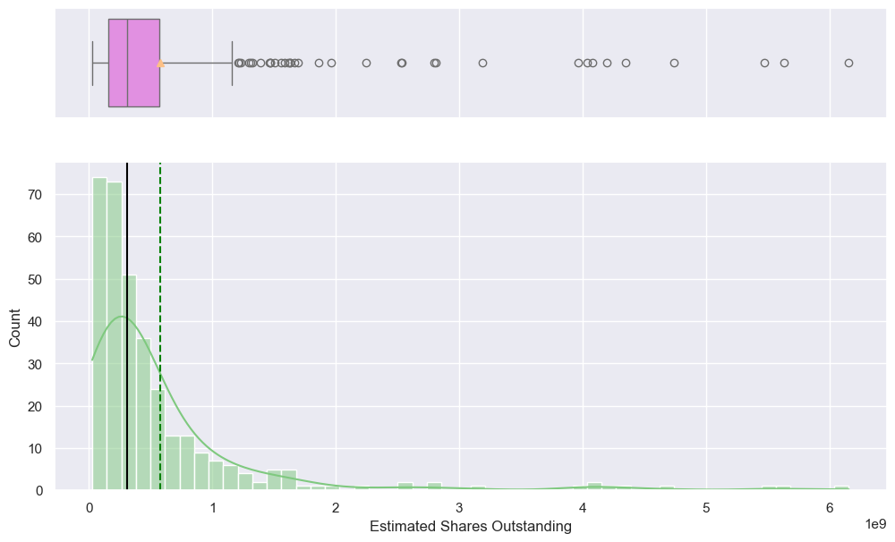

```python
histogram_boxplot(df, feature="Estimated Shares Outstanding", figsize=(12, 7), kde=True, bins=None)
```

#### P/E Ratio

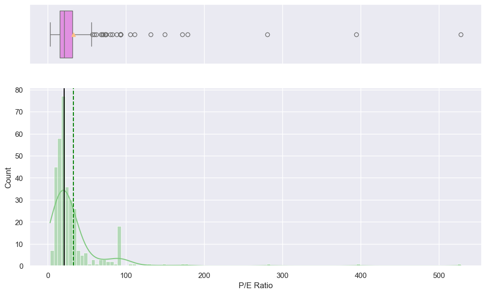

```python
histogram_boxplot(df, feature="P/E Ratio", figsize=(12, 7), kde=True, bins=None)
```

#### P/B Ratio

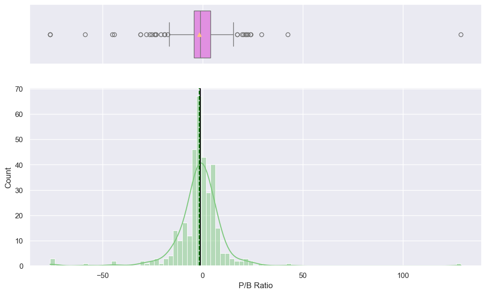

```python
histogram_boxplot(df, feature="P/B Ratio", figsize=(12, 7), kde=True, bins=None)
```

#### Corelation Heatmap

```python
# dropping non-numeric columns
df_num = df.copy()
```

```python
df_num = df_num.drop(columns=['Ticker Symbol', 'Security', 'GICS Sector', 'GICS Sub Industry'])
# df_num.head()
```

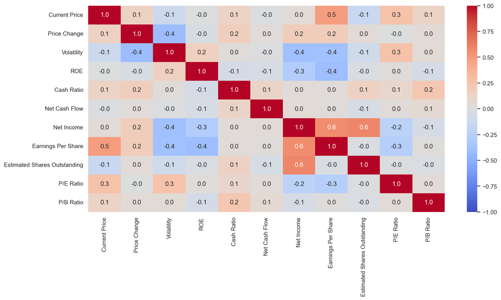

```python
plt.figure(figsize=(15, 7))
sns.heatmap(df_num.corr(), annot=True, vmin=-1, vmax=1, fmt=".1f", cmap="coolwarm");
```

The heatmap above indicates that there is not a problem with multicolinarity.

## Data Preprocessing

- Duplicate value check
- Missing value treatment
- Outlier check
- Feature engineering (if needed)
- Any other preprocessing steps (if needed)

#### Duplicate Value Check

```python
num_duplicates = df.duplicated().sum()
print(f"Number of duplicates: {num_duplicates}")
```

```
Number of duplicates: 0
```

There are no duplicates in this dataset.

#### Missing Value Treatment

```python
missing_values = df.isnull().sum()
print("Missing values in the DataFrame:")
print(missing_values)
```

```
Missing values in the DataFrame:
Ticker Symbol                   0
Security                        0
GICS Sector                     0
GICS Sub Industry               0
Current Price                   0
Price Change                    0
Volatility                      0
ROE                             0
Cash Ratio                      0
Net Cash Flow                   0
Net Income                      0
Earnings Per Share              0
Estimated Shares Outstanding    0
P/E Ratio                       0
P/B Ratio                       0
dtype: int64
```

There are no missing values.

#### Outlier Treatment

From the EDA we noticed a lot of outliers.

```python
# Outliers capped at 3 standard deviations
subject = 'Current Price'

mean = df[subject].mean()
std = df[subject].std()

k=3
lower_bound = mean - k * std
upper_bound = mean + k * std

df[subject] = np.where(df[subject] > upper_bound, upper_bound, df[subject])
df[subject] = np.where(df[subject] < lower_bound, lower_bound, df[subject])
```

```python
# Outliers capped at 3 standard deviations
subject = 'ROE'

mean = df[subject].mean()
std = df[subject].std()

k=3
lower_bound = mean - k * std
upper_bound = mean + k * std

df[subject] = np.where(df[subject] > upper_bound, upper_bound, df[subject])
df[subject] = np.where(df[subject] < lower_bound, lower_bound, df[subject])
```

```python
# Outliers capped at 3 standard deviations
subject = 'Price Change'

mean = df[subject].mean()
std = df[subject].std()

k=3
lower_bound = mean - k * std
upper_bound = mean + k * std

df[subject] = np.where(df[subject] > upper_bound, upper_bound, df[subject])
df[subject] = np.where(df[subject] < lower_bound, lower_bound, df[subject])
```

```python
# Outliers capped at 3 standard deviations
subject = 'Volatility'

mean = df[subject].mean()
std = df[subject].std()

k=3
lower_bound = mean - k * std
upper_bound = mean + k * std

df[subject] = np.where(df[subject] > upper_bound, upper_bound, df[subject])
df[subject] = np.where(df[subject] < lower_bound, lower_bound, df[subject])
```

```python
# Outliers capped at 3 standard deviations
subject = 'Cash Ratio'

mean = df[subject].mean()
std = df[subject].std()

k=3
upper_bound = mean + k * std

df[subject] = np.where(df[subject] > upper_bound, upper_bound, df[subject])
```

```python
# Outliers capped at 3 standard deviations
subject = 'Net Cash Flow'

mean = df[subject].mean()
std = df[subject].std()

k=2
lower_bound = mean - k * std
upper_bound = mean + k * std

df[subject] = np.where(df[subject] > upper_bound, upper_bound, df[subject])
df[subject] = np.where(df[subject] < lower_bound, lower_bound, df[subject])
```

```python
# Outliers capped at 3 standard deviations
subject = 'Net Income'

mean = df[subject].mean()
std = df[subject].std()

k=3
lower_bound = mean - k * std
upper_bound = mean + k * std

df[subject] = np.where(df[subject] > upper_bound, upper_bound, df[subject])
df[subject] = np.where(df[subject] < lower_bound, lower_bound, df[subject])
```

```python
# Outliers capped at 3 standard deviations
subject = 'Earnings Per Share'

mean = df[subject].mean()
std = df[subject].std()

k=3
lower_bound = mean - k * std
upper_bound = mean + k * std

df[subject] = np.where(df[subject] > upper_bound, upper_bound, df[subject])
df[subject] = np.where(df[subject] < lower_bound, lower_bound, df[subject])
```

```python
# Outliers capped at 3 standard deviations
subject = 'P/E Ratio'

mean = df[subject].mean()
std = df[subject].std()

k=3
lower_bound = mean - k * std
upper_bound = mean + k * std

df[subject] = np.where(df[subject] > upper_bound, upper_bound, df[subject])
df[subject] = np.where(df[subject] < lower_bound, lower_bound, df[subject])
```

```python
# Outliers capped at 3 standard deviations
subject = 'Estimated Shares Outstanding'

mean = df[subject].mean()
std = df[subject].std()

k=3
upper_bound = mean + k * std

df[subject] = np.where(df[subject] > upper_bound, upper_bound, df[subject])
```

```python
# Outliers capped at 3 standard deviations
subject = 'P/B Ratio'

mean = df[subject].mean()
std = df[subject].std()

k=3
lower_bound = mean - k * std
upper_bound = mean + k * std

df[subject] = np.where(df[subject] > upper_bound, upper_bound, df[subject])
df[subject] = np.where(df[subject] < lower_bound, lower_bound, df[subject])
```

## EDA 2

- It is a good idea to explore the data once again after manipulating it.

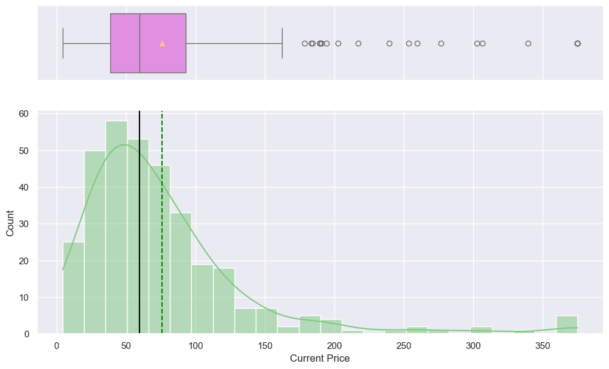

```python
histogram_boxplot(df, feature="Current Price", figsize=(12, 7), kde=True, bins=None)
```

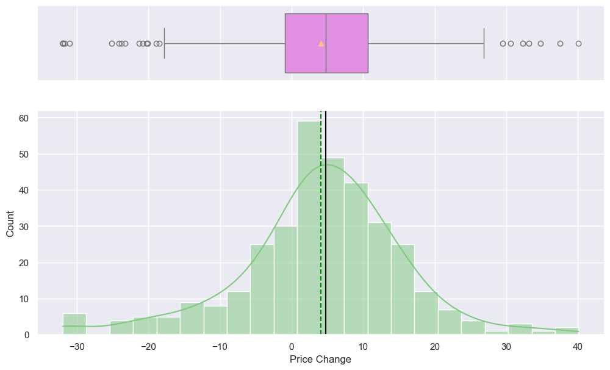

```python
histogram_boxplot(df, feature="Price Change", figsize=(12, 7), kde=True, bins=None)
```

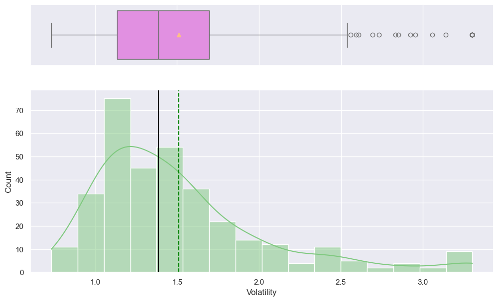

```python
histogram_boxplot(df, feature="Volatility", figsize=(12, 7), kde=True, bins=None)
```

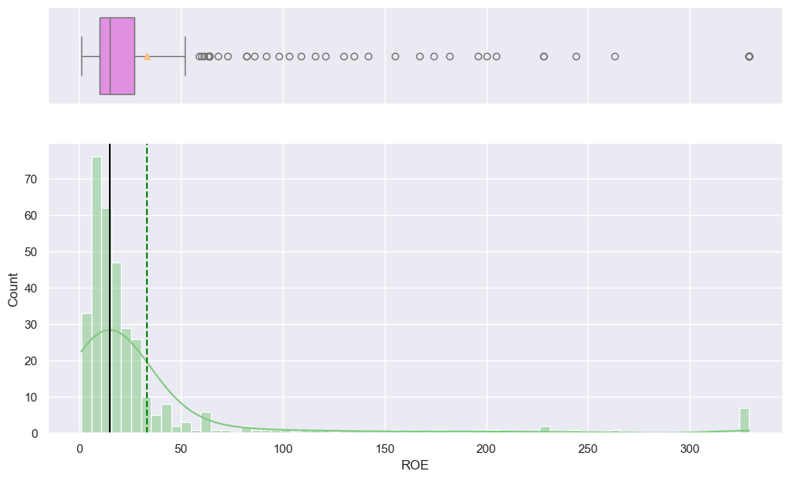

```python
histogram_boxplot(df, feature="ROE", figsize=(12, 7), kde=True, bins=None)
```

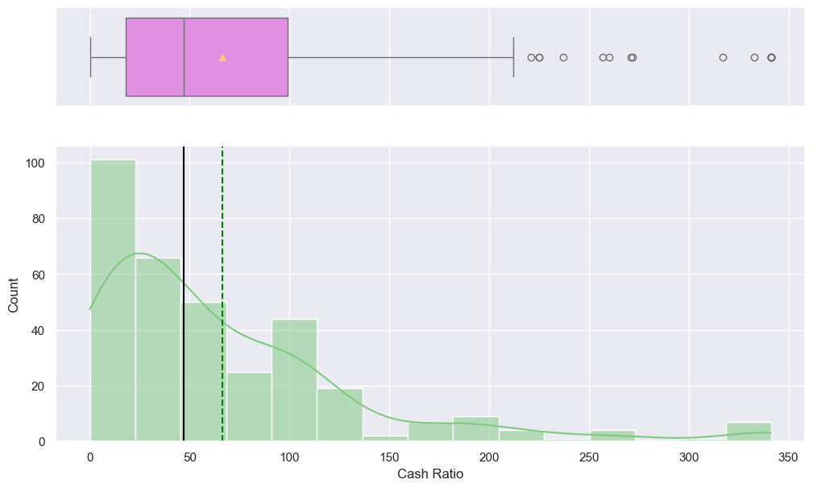

```python
histogram_boxplot(df, feature="Cash Ratio", figsize=(12, 7), kde=True, bins=None)
```

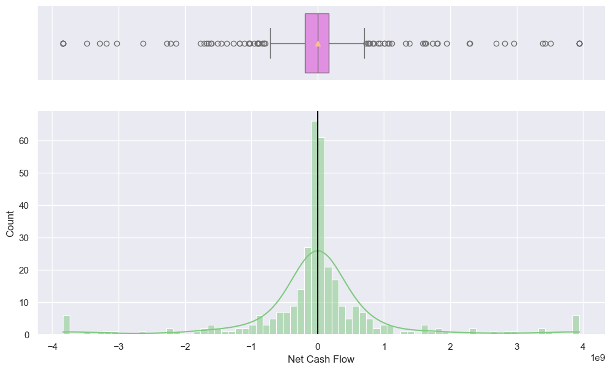

```python
histogram_boxplot(df, feature="Net Cash Flow", figsize=(12, 7), kde=True, bins=None)
```

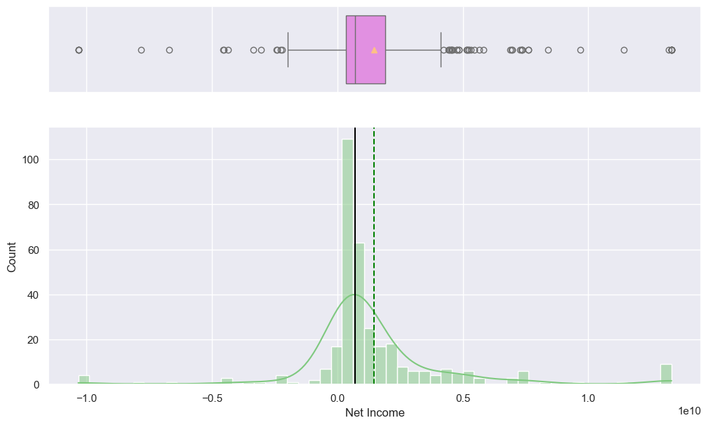

```python
histogram_boxplot(df, feature="Net Income", figsize=(12, 7), kde=True, bins=None)
```

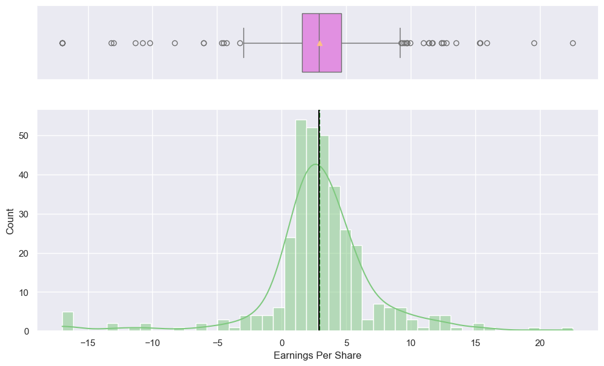

```python
histogram_boxplot(df, feature="Earnings Per Share", figsize=(12, 7), kde=True, bins=None)
```

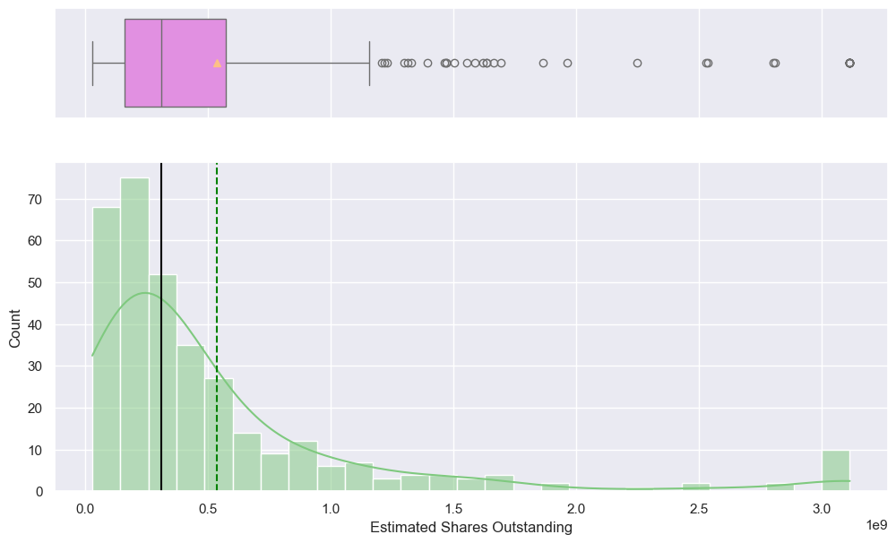

```python
histogram_boxplot(df, feature="Estimated Shares Outstanding", figsize=(12, 7), kde=True, bins=None)
```

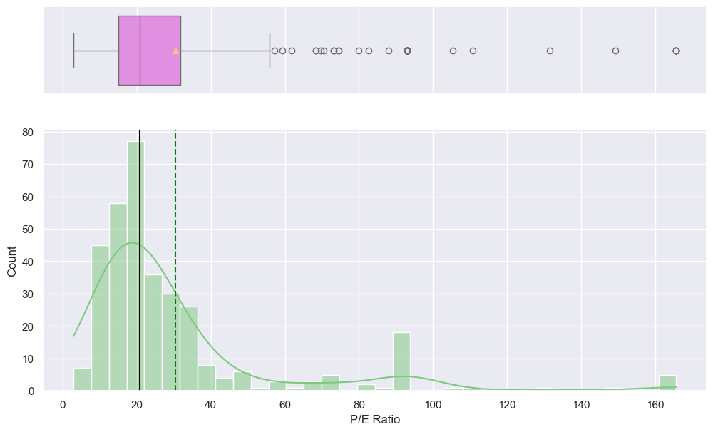

```python
histogram_boxplot(df, feature="P/E Ratio", figsize=(12, 7), kde=True, bins=None)
```

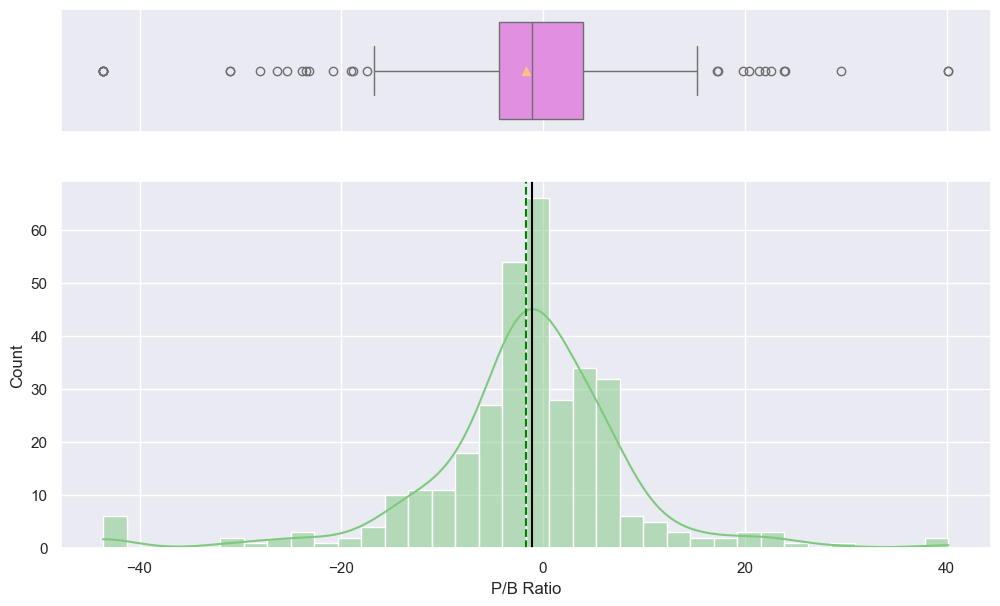

```python
histogram_boxplot(df, feature="P/B Ratio", figsize=(12, 7), kde=True, bins=None)
```

Even with capping the outliers at 3 standard deviations there are still a lot of outliers.

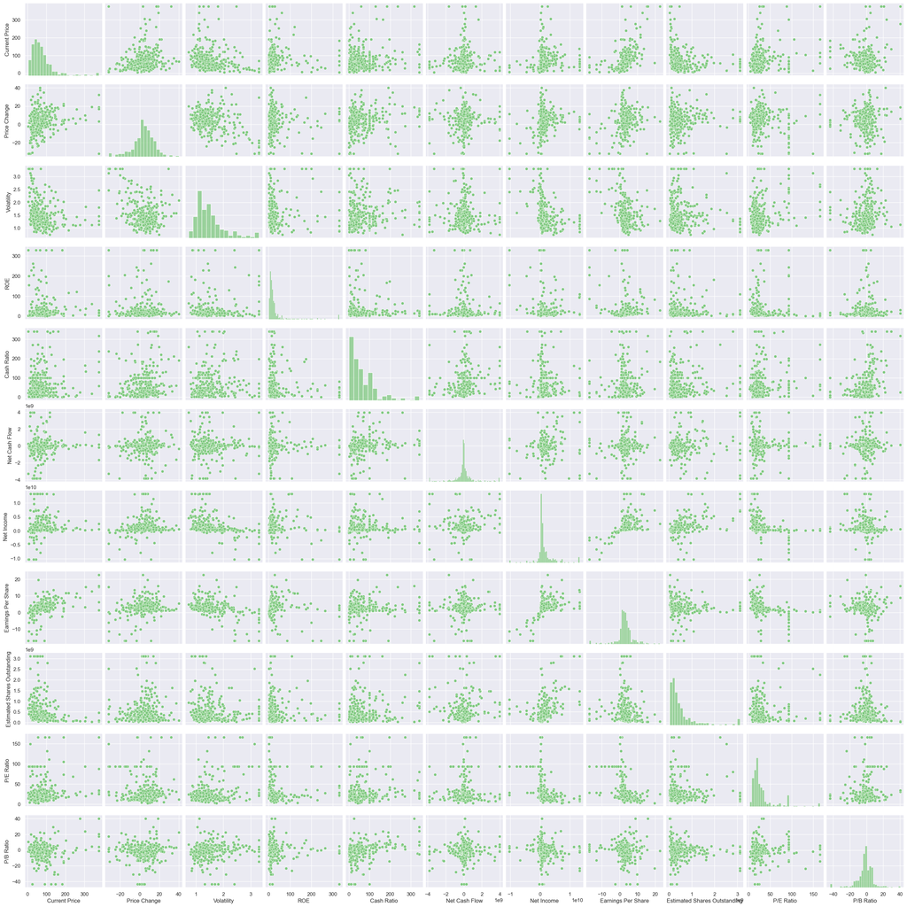

```python
sns.pairplot(df);
```